# Combining Data Type Visualisations

Best practices for visualising multiple data types

## 1 Combining Plots

No single visual representation is perfect, and it is often useful to combine representations to combine their advantages, or offset disadvantages, as with Figure 1, Figure 2, and Figure 3), below.

**Tip**

Tools like `R` and `ggplot` make these complex figures straightforward to generate. Tools like `Excel` do not.

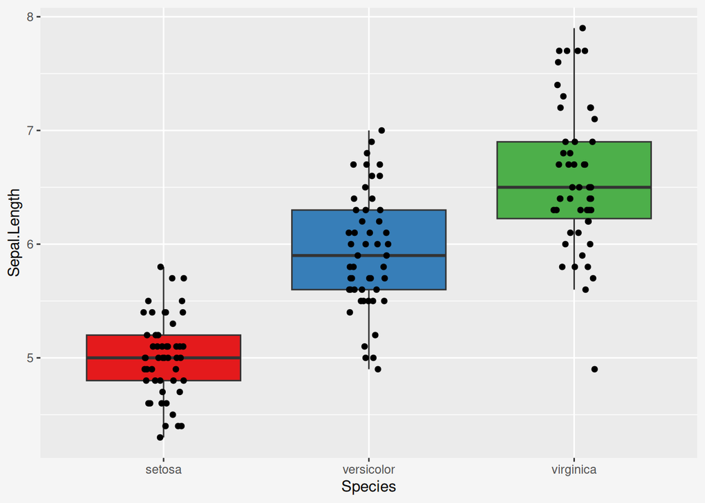

Figure 1: Boxplot/box-and-whisker plot of sepal length for each species from the `iris` dataset, with jittered scatterplot.

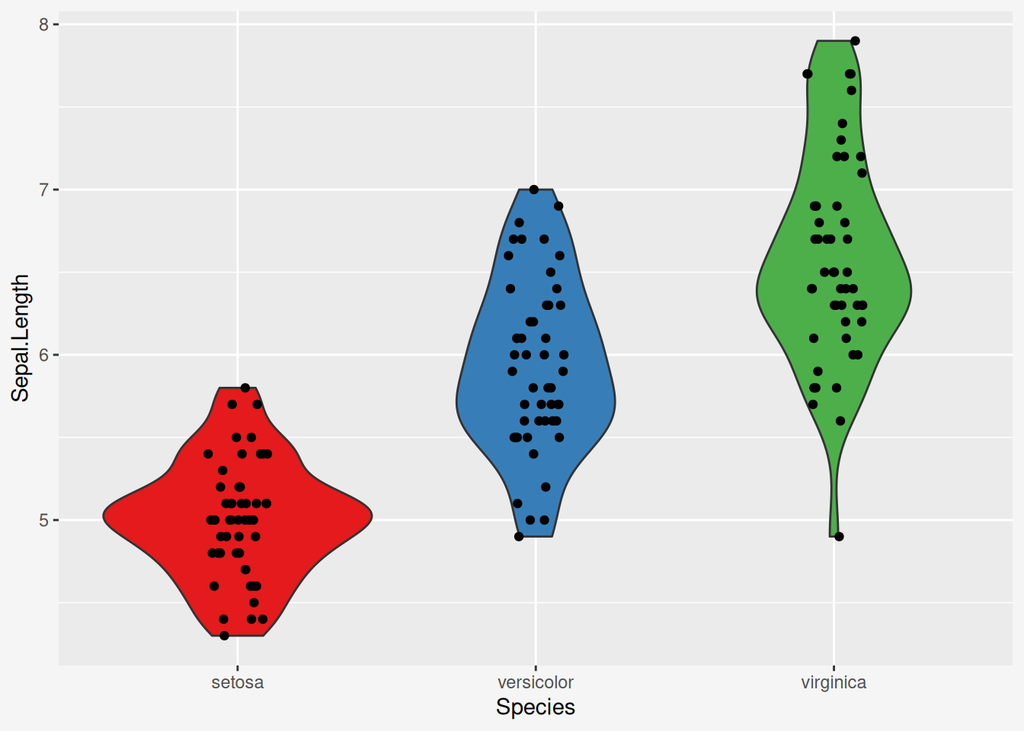

Figure 2: Violin plot of sepal length for each species from the `iris` dataset, with jittered scatterplot.

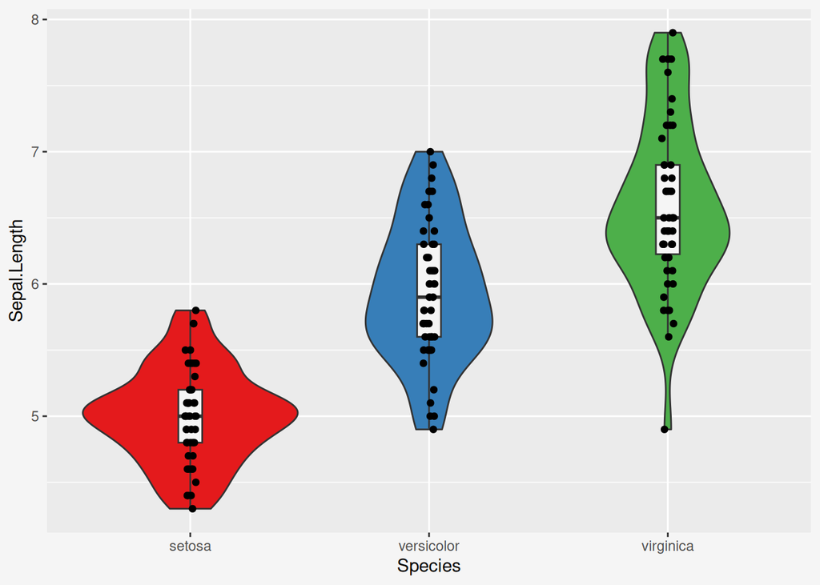

Figure 3: Vioin and boxplots of sepal length for each species from the `iris` dataset, with jittered scatterplot.

### 1.1 Bar Chart

For comparison, we present a common (and less informative) literature representation of this kind of data: a bar chart with error bars showing standard deviation of each dataset.

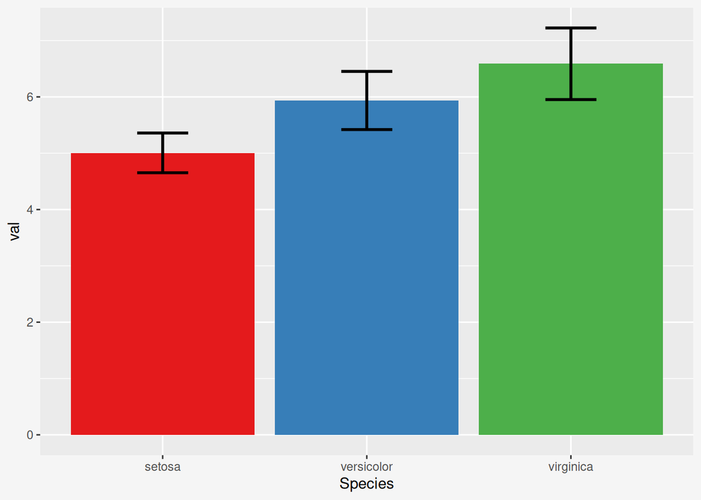

Figure 4: Bar chart of sepal length for each species from the `iris` dataset, with error bars representing standard deviation

**Callout-questionQuestion**

1. Which visualisations do you think made it easiest for you to interpret the data?

## 2 Pairs Plots

Tools like `GGally` and `ggplot2` in `R` provide a *pairs plot* graphics that combine the best-practice versions of the above representations to get a quick overview of a dataset. The `iris` and `titanic` datasets are summarised below in Figure 5 and Figure 6.

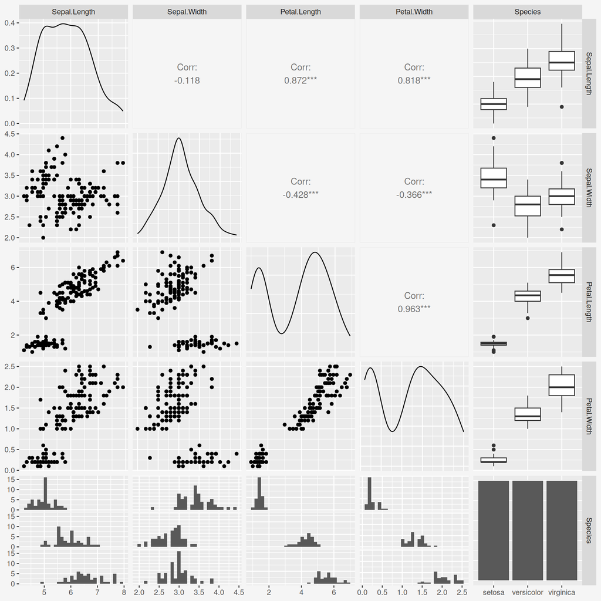

Figure 5: Pairs plot of `iris` data, providing an overview of relationships between variables.

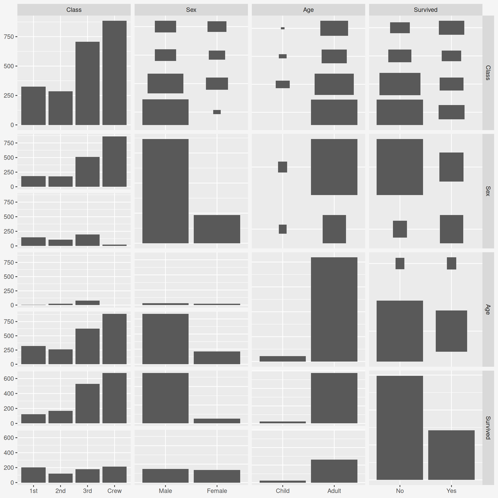

Figure 6: Pairs plot of `titanic` data, providing an overview of relationships between variables.

**Callout-questionsQuestions**

1. Which data representations does the pairs plot use?
2. Which visualisation is used for comparing each type of data?
3. Do you agree that the right choice was made for each data type?
4. How would you refine these pairs plots?

[Github](https://github.com/sipbs-compbiol) Email